# Unit 3 Review

STAT 240 - Fall 2025

Robert Sholl

# Confidence Intervals

## Algorithm

1. Compute or identify the point estimate
2. Compute or identify standard deviation and sample size
   - Check CLT
3. Compute $t_{\alpha/2}$ or $z_{\alpha/2}$ depending on CI type
4. Compute margin of error
5. Add and subtract margin of error to point estimate

## Mean CI

$$\begin{aligned}
\text{Point Estimate} = \bar{x} \\
\\
\text{Margin of Error} = t_{\alpha/2}\frac{s}{\sqrt{n}} \text{ or } z_{\alpha/2}\frac{s}{\sqrt{n}} \\
\\
\text{CI} = \bar{x} \pm t_{\alpha/2}\frac{s}{\sqrt{n}} \text{ or } z_{\alpha/2}\frac{s}{\sqrt{n}}
\end{aligned}$$

## Proportion CI

$$\begin{aligned}
\text{Point Estimate} = \hat{p} \\
\\
\text{Margin of Error} = z_{\alpha/2}\sqrt{\frac{p(1-p)}{n}} \\
\\
\text{CI} = \hat{p} \pm z_{\alpha/2}\sqrt{\frac{p(1-p)}{n}}
\end{aligned}$$

## Practice 1

> The lower bound of a certain $95\%$ confidence interval is equal to $10.78$, with a sample standard deviation of $s=16.34$ and a sample size of $n=40$. Calculate the upper bound of the interval.

## Practice 2

> Given sample proportion of $\hat{p} = 0.129$, sample size of $n=984$, and population proportion estimate of $p = 0.118$, write out the full formula for calculating the confidence interval of this proportion using all of the numeric values. You do not have to finish the calculation.

# Null Hypothesis Significance Testing

## Vocab

Null Hypothesis $H_0$: the statement we are holding as **known and established information**

- i.e., The average body weight of an adult cat is $10$ lbs.

$$H_0:\mu=10$$

Alternate Hypothesis $H_a$ or $H_1$: The statement we are **testing to determine the accuracy of**

## Practical Example

> I believe that the cats I interact with regularly have a **different** average body weight than the population

$$H_0:\mu=10$$

$$H_a:\mu \neq 10$$

## Practical Example

- Test Statistic $t^*$

A value calculated as **part** of the hypothesis testing process. We place it into a $t$-table (or $z$-table depending) to get a $p$-value.

$$t^* = \frac{\bar{x} - \mu_0}{{s}/{\sqrt{n}}}$$

## Practical Example

- I weighed $4$ of my friends cats and my own cat and found that their average body weight was $8$ pounds, with a standard deviation of $2.49$

$$t^* = \frac{8 - 10}{{2.49}/{\sqrt{5}}}$$

$$t^*=-1.796039$$

## Practical Example

Significance level ($\alpha$): The percentage probability we incur Type 1 Error in our hypothesis testing process

- I want to test my cat weight hypothesis at $\alpha=0.05$

## Practical Example

p-value: The final statistic calculated in a hypothesis test, **used to determine if we reject or fail to reject the null hypothesis**

$$2*P(T>t^*)=0.15$$

$$0.15>\alpha \quad \text{Fail to Reject} \ H_0$$

## Statistical Significance

We refer to a **result** as **statistically significant** if we tested it against a **null hypothesis** and proceeded to **reject** the null hypothesis

> “There is insufficient evidence to suggest that the body weight of the cats that interact with regularly have a **statistically** significant difference in average body weight from the population”

## But remember

- p-values aren’t law
- Statistical significance isn’t all important
  - *scientific* significance is
- If one of *my* students throws away scientifically relevant results because of $p = 0.051$ …

## Phoebe will be upset

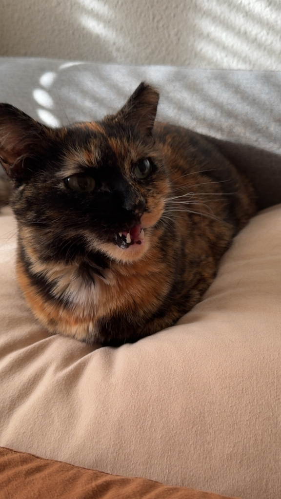

## Practice 1

Identify the following statements are true or false.

1. If $P = 0.03$, the result is statistically significant at the $\alpha = 0.05$ level
2. If $P = 0.03$, the null hypothesis is rejected at the $\alpha = 0.05$ level
3. If $P = 0.03$, the result is statistically significant at the $\alpha = 0.01$ level
4. If $P = 0.03$, the null hypothesis is rejected at the $\alpha = 0.01$ level

## Practice 2

> The average uptake of oxygen in the general adult population is 38.2 ml/kg. A sample of 40 joggers gave a sample mean of 40.5 ml/kg with a standard deviation of 6.0 ml/kg for oxygen uptake. A physician would like to know whether or not joggers have a significantly higher average oxygen uptake than the general population.

## Practice 2 (Still)

Select the correct interval for the P-value.

1. P-value $\leq0.01$
2. $0.01<$ P-value $\leq0.025$
3. $0.025<$ P-value $\leq0.05$
4. P-value $>0.05$

# Two mean NHST

## Practical Example

$$\begin{array}{|c|c|c|c|c|}
\hline
\text{Automobile} & 1 & 2 & 3 & 4\\
\hline
\text{After Tune-up} & 35.44 & 35.17 & 31.07 & 31.57 \\
\hline
\text{Before Tune-up} & 33.76 & 34.30 & 29.55 & 30.90 \\
\hline
\text{Automobile} & 5 & 6 & 7 & 8 \\
\hline
\text{After Tune-up} & 26.48 & 23.11 & 25.18 & 32.39 \\
\hline
\text{Before Tune-up} & 24.92 & 21.78 & 24.30 & 31.25 \\
\hline
\end{array}$$

## Practical Example

$$H_0: \mu_d - \mu_0 = 0$$

$$H_a: \mu_d - \mu_0 \neq 0$$

## Practical Example

$$\begin{aligned}
\bar{d} = & \sum_{i=1}^n \frac{x_1{_i}-x_2{_i}}{n}\\
\bar{d} = & \ \frac{1.68 + 0.87 + \ldots + 1.14}{8} \approx 1.2063 \\
\end{aligned}$$

$$\begin{aligned}
s_d = & \ \sqrt{\sum_{i=1}^n\frac{(d_i - \bar{d})}{n-1}}\\
s_d = & \ \sqrt{\frac{(1.68 - 1.206)^2 + \ldots + (1.14 - 1.206)^2}{7}} \approx 0.3732
\end{aligned}$$

# Fisher’s Exact

## Algorithm

1. Define null hypothesis
   - Natural language
2. Set up contingency table
3. Perform test

> Very straight forward

## Fisher’s assumptions

- No reject/fail to reject/accept conditions
  - Significant or not significant
- $p$-values are a interpreted as the probability we observe those results *if* the null is true
  - They *can* show magnitude
- Data should be counts, the test assumes a hypergeometric is appropriate

## Odds Ratios

- Describe the strength of association between two events
- Built from contingency table
- “(Group) is (Odds ratio) times more likely to be (Effect) compared to (Inverse group)”

$$OR = \frac{a / b}{c / d}$$

# Neyman-Pearson

## Algorithm

1. Establish effect size
2. Identify the optimal (uniformly most powerful) test
3. Propose the main and alternate hypothesis
4. Determine rejection region ($\alpha$)
5. Calculate sample size to achieve good power
6. Perform test and compute critical value

## N-P Assumptions

- *a priori*: everything is set prior to observing data
  - Ideally prior to performing the experiment
- Main and alternate represent two separate populations
  - To reject one is to accept the other
- p-values are just another representation of critical value
  - They aren’t appropriate measurements of effect magnitude

## Difference Table

$$\begin{array}{|c|c|c|c|}
\hline
\text{Method} & \text{Hypotheses} & \text{Test} & \text{Results} \\
\hline
\text{NHST} & H_0 \text{ & } H_a & \text{Convention} & \text{Reject or fail}\\
\hline
\text{Fisher} & H_0 & \text{Convention} & \text{Significant or not}\\
\hline
\text{Neyman-Pearson} & H_M \text{ & } H_A& \text{UMP} & \text{Accept/Reject} \\
\hline
\end{array}$$